# PEC1_Analisis Omicos

Daniel Tapia García

2024-11-04

### 0. PREPARATIVOS PREVIOS

```r
###Primero vamos a determinar el directorio de trabajo
setwd("~/R/Directorio de Trabajo/Master en Bioinfo/Analisis Datos Omicos/PEC1")
wd =getwd()

#Instalamos las librerias necesarias
if (!requireNamespace("BiocManager", quietly = TRUE))
    install.packages("BiocManager")

BiocManager::install("metabolomicsWorkbenchR")

install.packages("git2r")
```

```
## Error in contrib.url(repos, "source"): trying to use CRAN without setting a mirror
```

```r
install.packages("FSA")
```

```
## Error in contrib.url(repos, "source"): trying to use CRAN without setting a mirror
```

```r
library(git2r)
library(metabolomicsWorkbenchR)
library(SummarizedExperiment)
library(tidyr)
library(dplyr)
library(stringr)
library(broom)
library(purrr)
library(openxlsx)
library(FSA)
```

### 1. OBTENCIÓN Y CARGA DE LOS DATOS

```r
#Obtenemos los archivos para la PEC, introducimos la URL del repositorio
repo_url = "https://github.com/nutrimetabolomics/metaboData.git"

# Clonamos el repositorio en el directorio de trabajo, en una carpeta específica
git2r::clone(repo_url, local_path = file.path(wd, "metaboData"))
```

```
## cloning into 'C:/Users/danit/Documents/R/Directorio de Trabajo/Master en Bioinfo/Analisis Datos Omicos/PEC1/metaboData'...
```

```
## Error in git2r::clone(repo_url, local_path = file.path(wd, "metaboData")): Error in 'git2r_clone': 'C:/Users/danit/Documents/R/Directorio de Trabajo/Master en Bioinfo/Analisis Datos Omicos/PEC1/metaboData' exists and is not an empty directory
```

Vamos a centrarnos en el Dataset 2024-fobitools-UseCase_1, que contiene los datos experimentales para el paper.

*“LC-MS Based Approaches to Investigate Metabolomic Differences in the Urine of Young Women after Drinking Cranberry Juice or Apple Juice”* https://www.metabolomicsworkbench.org/data/DRCCMetadata.php?Mode=Study&StudyID=ST000291

```r
#Podemos utilizar la función do_query de metabolomicsWorkbenchR para conectar directamente con la API de metabolomicsworkbench y obtener los IDS de estos estudios (aunque aparecen en el archivo .rm del repositorio, usaremos ese archivo para confirmar)

query = do_query(
    context = 'study',
    input_item = 'study_title',
    input_value = 'Cranberry',
    output_item = 'summary'
)

df_query= query[1:6,c(1:5)]
knitr::kable(df_query,format="markdown")
```

|  | study_id | study_title | species | institute | analysis_type |
| --- | --- | --- | --- | --- | --- |
| 1 | ST000292 | LC-MS Based Approaches to Investigate Metabolomic Differences in the Plasma of Young Women after Drinking Cranberry Juice or Apple Juice | Homo sapiens | University of Florida | LC-MS |
| 2 | ST000291 | LC-MS Based Approaches to Investigate Metabolomic Differences in the Urine of Young Women after Drinking Cranberry Juice or Apple Juice | Homo sapiens | University of Florida | LC-MS |
| NA | NA | NA | NA | NA | NA |
| NA.1 | NA | NA | NA | NA | NA |
| NA.2 | NA | NA | NA | NA | NA |
| NA.3 | NA | NA | NA | NA | NA |

```r
#Veremos dos entradas, una de ellas coincide con el ID de nuestro experimento del repositorio (las medidas de Orina, ST000291), la otras es la referente a las medidas de plasma.

#--También aparecen filas de NA, esto es debido a las dimensiones elegidas para ver la matriz de resultados, que es más grande que el total de resultados encontrados.
```

```r
#Por tanto, volvemos a hcer una consulta para descargar esos datos, teniendo en cuenta de cambiar los argumentos para ingresar el ID y obtener el Summarized Experiment en lugar del resumen (tal como indica la documentación del paquete)

SE = do_query(
    context = 'study',
    input_item = 'study_id',
    input_value = 'ST000291',
    output_item = 'SummarizedExperiment' # or 'DatasetExperiment'
)

#Vemos que en el elemento descargado tenemos 2 experimentos, parece que tienen diferente longitud
summary(SE)
```

```
##          Length Class                Mode
## AN000464 1786   SummarizedExperiment S4
## AN000465  747   SummarizedExperiment S4
```

```r
#Ambos tienen la estructura de un Summarized Experiment, así que extraeremos los datos de su interior
SE
```

```
## $AN000464
## class: SummarizedExperiment
## dim: 1786 45
## metadata(8): data_source study_id ... description subject_type
## assays(1): ''
## rownames(1786): ME104202 ME104203 ... ME105898 ME105899
## rowData names(3): metabolite_name metabolite_id refmet_name
## colnames(45): a1 a10 ... c8 c9
## colData names(6): local_sample_id study_id ... raw_data Treatment_
##
## $AN000465
## class: SummarizedExperiment
## dim: 747 45
## metadata(8): data_source study_id ... description subject_type
## assays(1): ''
## rownames(747): ME105925 ME105926 ... ME106646 ME106647
## rowData names(3): metabolite_name metabolite_id refmet_name
## colnames(45): a1 a10 ... c8 c9
## colData names(6): local_sample_id study_id ... raw_data Treatment_
```

### 2. ANÁLISIS DE METADATOS, GRUPOS EXPERIMENTALES Y LECTURAS LCMS

Procedemos a analizar la estructura de esos experimentos

```r
#Primero los metadatos de ambos experimentos

metadata_1=as.data.frame(metadata(SE$AN000464), stringsAsFactors = FALSE)
metadata_2=as.data.frame(metadata(SE$AN000465), stringsAsFactors = FALSE)

metaD_comparacion=data.frame(Ensayo1 = unlist(metadata_1),
                                Ensayo2 = unlist(metadata_2))

#La diferencia entre uno y otro es que en el primero se usa ionización positiva para el LCMS y en el segundo, negativa.
knitr::kable(metaD_comparacion,format="markdown")
```

|  | Ensayo1 | Ensayo2 |
| --- | --- | --- |
| data_source | Metabolomics Workbench | Metabolomics Workbench |
| study_id | ST000291 | ST000291 |
| analysis_id | AN000464 | AN000465 |
| analysis_summary | ESI Positive mode | ESI Negative mode |
| units | Peak area | Peak area |
| name | ST000291:AN000464 | ST000291:AN000465 |
| description | LC-MS Based Approaches to Investigate Metabolomic Differences in the Urine of Young Women after Drinking Cranberry Juice or Apple Juice | LC-MS Based Approaches to Investigate Metabolomic Differences in the Urine of Young Women after Drinking Cranberry Juice or Apple Juice |
| subject_type | NA | NA |

```r
#Guardamos los resultados en el directorio
write.xlsx(metaD_comparacion, file="Comparación_metadatos.xlsx")
```

Dentro del SE tenemos dos ensayos, que corresponden a los dos análisis hechos con LCMS, esto coincide con lo que podemos ver en el resumen web del estudio (fila Ion Mode)

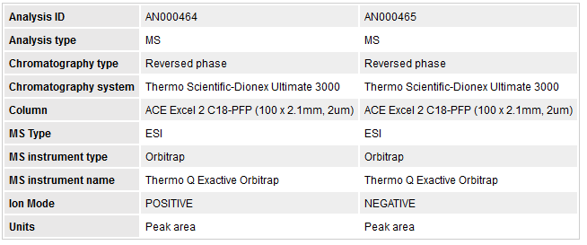

```r
#Vamos pues a analizar diferentes aspectos de estas experiencias, por ejemplo, la cantidad de compuestos obtenidos en cada método y cuales son

compounds_1=as.data.frame(SE$AN000464@elementMetadata@listData, stringsAsFactors = FALSE)
nc1=SE$AN000464@elementMetadata@nrows

compounds_2=as.data.frame(SE$AN000465@elementMetadata@listData, stringsAsFactors = FALSE)
nc2=SE$AN000465@elementMetadata@nrows

#Vemos como tiene el nombre de compuesto, un identificador de metabolito en la base de datos de workbench, y el nombre al que hace referencia (aunque no aparece para todos)

comp_total=rbind(compounds_1,compounds_2)

cat("Con polaridad positiva se obtuvieron ",nc1," compuestos y con polaridad negativa ",nc2, "los compuestos podrán ser vistos en los correspondientes archivos excel.")
```

```
## Con polaridad positiva se obtuvieron  1786  compuestos y con polaridad negativa  747 los compuestos podrán ser vistos en los correspondientes archivos excel.
```

```r
knitr::kable(head(compounds_1),format="markdown")
```

| metabolite_name | metabolite_id | refmet_name |
| --- | --- | --- |
| 10-Desacetyltaxuyunnanin C | ME104202 |  |
| 10-Hydroxydecanoic acid | ME104203 | 10-Hydroxydecanoic acid |
| 10-Oxodecanoate_1 | ME104204 | 10-Oxodecanoic acid |
| 10-Oxodecanoate_2 | ME104205 | 10-Oxodecanoic acid |
| 11beta,21-Dihydroxy-5beta-pregnane-3,20-dione | ME104206 | 11beta,21-Dihydroxy-5beta-pregnane-3,20-dione |
| 1,1-Dichloroethylene epoxide | ME104182 |  |

```r
knitr::kable(head(compounds_2),format="markdown")
```

| metabolite_name | metabolite_id | refmet_name |
| --- | --- | --- |
| 10-Deacetyl-2-debenzoylbaccatin III | ME105925 | 10-Deacetyl-2-debenzoylbaccatin III |
| 10-Oxodecanoate | ME105926 | 10-Oxodecanoic acid |
| 1,1-Diethyl-2-hydroxy-2-nitrosohydrazine_1 | ME105922 |  |
| 1,1-Diethyl-2-hydroxy-2-nitrosohydrazine_2 | ME105923 |  |
| 1,2-Dihydroxynaphthalene-6-sulfonate | ME105924 |  |
| 12-trans-Hydroxy juvenile hormone III | ME105927 |  |

```r
write.xlsx(compounds_1, file="compuestos_LCMS_Positivo.xlsx",rownames=FALSE)
write.xlsx(compounds_2, file="compuestos_LCMS_Negativo.xlsx",rownames=FALSE)
write.xlsx(comp_total, file="compuestos_total.xlsx",rownames=FALSE)
```

```r
#Vamos a extraer los grupos experimentales, que son los mismos en ambos analisis
grupos_experimentales=as.data.frame(colData(SE$AN000464), stringsAsFactors=FALSE)
knitr::kable(grupos_experimentales,format="markdown")
```

|  | local_sample_id | study_id | sample_source | mb_sample_id | raw_data | Treatment_ |
| --- | --- | --- | --- | --- | --- | --- |
| a1 | a1 | ST000291 | Urine | SA013237 |  | Urine after drinking apple juice |
| a10 | a10 | ST000291 | Urine | SA013236 |  | Urine after drinking apple juice |
| a11 | a11 | ST000291 | Urine | SA013246 |  | Urine after drinking apple juice |
| a12 | a12 | ST000291 | Urine | SA013244 |  | Urine after drinking apple juice |
| a13 | a13 | ST000291 | Urine | SA013245 |  | Urine after drinking apple juice |
| a14 | a14 | ST000291 | Urine | SA013243 |  | Urine after drinking apple juice |
| a15 | a15 | ST000291 | Urine | SA013242 |  | Urine after drinking apple juice |
| a16 | a16 | ST000291 | Urine | SA013240 |  | Urine after drinking apple juice |
| a17 | a17 | ST000291 | Urine | SA013241 |  | Urine after drinking apple juice |
| a2 | a2 | ST000291 | Urine | SA013239 |  | Urine after drinking apple juice |
| a4 | a4 | ST000291 | Urine | SA013238 |  | Urine after drinking apple juice |
| a6 | a6 | ST000291 | Urine | SA013235 |  | Urine after drinking apple juice |
| a7 | a7 | ST000291 | Urine | SA013234 |  | Urine after drinking apple juice |
| a8 | a8 | ST000291 | Urine | SA013232 |  | Urine after drinking apple juice |
| a9 | a9 | ST000291 | Urine | SA013233 |  | Urine after drinking apple juice |
| b1 | b1 | ST000291 | Urine | SA013221 |  | Baseline urine |
| b10 | b10 | ST000291 | Urine | SA013231 |  | Baseline urine |
| b11 | b11 | ST000291 | Urine | SA013226 |  | Baseline urine |
| b12 | b12 | ST000291 | Urine | SA013223 |  | Baseline urine |
| b13 | b13 | ST000291 | Urine | SA013218 |  | Baseline urine |
| b14 | b14 | ST000291 | Urine | SA013224 |  | Baseline urine |
| b15 | b15 | ST000291 | Urine | SA013217 |  | Baseline urine |
| b16 | b16 | ST000291 | Urine | SA013219 |  | Baseline urine |
| b17 | b17 | ST000291 | Urine | SA013220 |  | Baseline urine |
| b2 | b2 | ST000291 | Urine | SA013222 |  | Baseline urine |
| b4 | b4 | ST000291 | Urine | SA013227 |  | Baseline urine |
| b6 | b6 | ST000291 | Urine | SA013229 |  | Baseline urine |
| b7 | b7 | ST000291 | Urine | SA013225 |  | Baseline urine |
| b8 | b8 | ST000291 | Urine | SA013228 |  | Baseline urine |
| b9 | b9 | ST000291 | Urine | SA013230 |  | Baseline urine |
| c1 | c1 | ST000291 | Urine | SA013252 |  | Urine after drinking cranberry juice |
| c10 | c10 | ST000291 | Urine | SA013247 |  | Urine after drinking cranberry juice |
| c11 | c11 | ST000291 | Urine | SA013255 |  | Urine after drinking cranberry juice |
| c12 | c12 | ST000291 | Urine | SA013260 |  | Urine after drinking cranberry juice |
| c13 | c13 | ST000291 | Urine | SA013259 |  | Urine after drinking cranberry juice |
| c14 | c14 | ST000291 | Urine | SA013258 |  | Urine after drinking cranberry juice |
| c15 | c15 | ST000291 | Urine | SA013256 |  | Urine after drinking cranberry juice |
| c16 | c16 | ST000291 | Urine | SA013257 |  | Urine after drinking cranberry juice |
| c17 | c17 | ST000291 | Urine | SA013261 |  | Urine after drinking cranberry juice |
| c2 | c2 | ST000291 | Urine | SA013253 |  | Urine after drinking cranberry juice |
| c4 | c4 | ST000291 | Urine | SA013251 |  | Urine after drinking cranberry juice |
| c6 | c6 | ST000291 | Urine | SA013250 |  | Urine after drinking cranberry juice |
| c7 | c7 | ST000291 | Urine | SA013248 |  | Urine after drinking cranberry juice |
| c8 | c8 | ST000291 | Urine | SA013249 |  | Urine after drinking cranberry juice |
| c9 | c9 | ST000291 | Urine | SA013254 |  | Urine after drinking cranberry juice |

```r
#Vemos como hay 3 clases experimentales, las lecturas basales, las lecturas tras beber zumo de manzana, y las lecturas tras beber zumo de arándanos
summary(grupos_experimentales)
```

```
##  local_sample_id      study_id         sample_source      mb_sample_id
##  Length:45          Length:45          Length:45          Length:45
##  Class :character   Class :character   Class :character   Class :character
##  Mode  :character   Mode  :character   Mode  :character   Mode  :character
##    raw_data                                        Treatment_
##  Length:45          Baseline urine                      :15
##  Class :character   Urine after drinking apple juice    :15
##  Mode  :character   Urine after drinking cranberry juice:15
```

```r
#Guardamos los resultados en el directorio
write.xlsx(grupos_experimentales, file="grupos_exp.xlsx",rownames=FALSE)
```

```r
#También vamos a extraer las hojas de resultados crudos para ambos analisis
raw_1=assay(SE$AN000464)
write.xlsx(raw_1, file="Lecturas_LCMS_Positivo.xlsx",rownames=FALSE)
raw_2=assay(SE$AN000465)
write.xlsx(raw_2, file="Lecturas_LCMS_Negativo.xlsx",rownames=FALSE)

#Creamos un único DF con los registros de todos los compuestos, primero los de perfil positivo y luego los negativos
datos_raw=rbind(raw_1,raw_2)

#Las dimensiones (nº de compuestos ~  nº pacientes) son
dim(raw_1)
```

```
## [1] 1786   45
```

```r
dim(raw_2)
```

```
## [1] 747  45
```

```r
dim(datos_raw)
```

```
## [1] 2533   45
```

### 3. ANÁLISIS DEL PROYECTO EN CONJUNTO

#### A) PREGUNTA BIOLÓGICA Y DISEÑO EXPERIMENTAL

Las Procianidinas son compuestos con actividad antioxidante, antibacteriana y antiinflamatoria, un enriquecimiento de este tipo de compuestos en la dieta puede tener efectos positivos en el individuo. El estudio tiene objetivo ver si la modificación de la dieta en alimentos altos en procianidinas tiene repercusión en el perfil metabólico (de orina en este caso) de los pacientes.

En el estudio se reclutaron 18 mujeres estudiantes de entre 21 y 29 años para incluir en su dieta productos altos en procianidinas a lo largo de 6 días, y en el 7º se les tomó una muestra de orina y posteriormente se dividieron aleatoriamente en dos grupos para suministrarles zumo de arándanos o de manzana durante los siguientes días. Tras dos semanas de “depuración”, el tratamiento en los grupos fue invertido. Se tomaron medidas del plasma y de orina de ambos grupos.

#### **B) OBTENCIÓN DE DATOS CRUDOS Y DEPURACIÓN DE DATOS**

Las muestras extraídas fueron sometidos a análisis de LCMS en polaridad positiva y negativa para cubrir un mayor abanico de moléculas.

Se utilizó un grupo “control” representado por los valores de orina medidos en los pactientes antes de someterse a los diferentes zumos (tras la modificiación inicial de dieta).

Se monitorizaron los valores en orina de los pacientes asignados a tomar zumo de arándanos o de manzana.

Los datos fueron curados y procesados tanto en cuanto que se eliminaron algunos registros puesto que algunos de los participantes no finalizaron el tratamiento o no entregaron todas las muestras, así que fueron eliminados del análisis.

Además, aunque en Workbench se representan datos con NA en los registros, este set de datos es usado como [demostración del paquete *fobitools*,](https://www.bioconductor.org/packages/devel/bioc//vignettes/fobitools/inst/doc/MW_ST000291_enrichment.html#scraping-metabolite-names-and-identifiers-with-rvest) y en ese análisis (y es una práctica habitual en otros) se han eliminado estos NA para asegurar que todos los compuestos que analizamos aparecen en todos los pacientes (puesto que si algunos no son detectables no aportarían información útil a la conclusión).

#### C) ANÁLISIS ESTADÍSTICO DE LOS DATOS

En la demostración de uso del paquete fobitools se llevan a cabo diferentes análisis estadísticos:

- Preprocesado mediante k_NearestNeighbours y logPareto para transformar y escalar los datos
- Aplicación de un [modelo Limma](https://academic.oup.com/nar/article/43/7/e47/2414268) para determinar los metabolitos significativamente diferenciales, en este caso se muestran los 10 metabolitos de significación mayor en cuanto a las diferencias entre los grupo de pacientes “basales-zumo de arandano”. Los ID de Pubchem, comparándolos con los valores correspondientes en la [web de WorkBench](https://www.metabolomicsworkbench.org/data/show_metabolites_by_study.php?STUDY_ID=ST000291&SORTFIELD=metabolite_name)
  - Dihydroxyfumarate; Sucralose; Methyl beta-d-galactoside; Furamizole; Dichlorophen; Nitramine;5-Methyl-3-isoxazolyl sulfate; Coenzyme B; Azinphos-ehthyl; Decarbamoylgonyautoxin

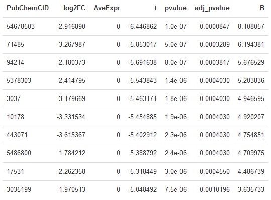

- **Estudio de enriquecimiento:** En la web de demostración del uso de FOBI no consiguen obtener los alimentos suministrados (zumos) como el resultado de procesado de sus metabolitos a través de un análisis de sobrerrepresentación. Sin embargo, cuando cambiaron su enfoque a un estudio de enriquecimiento genético (Gene Set Enrichment Analysis), sí lo consiguen.

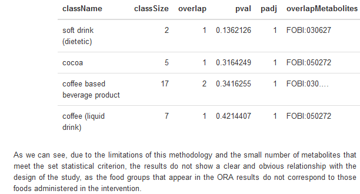

Ambas son metologias complejas, sin embargo, podemos acudir a la [propia web de workbench donde se nos permite hacer un ANOVA para los metabolitos analizados](https://www.metabolomicsworkbench.org/data/pca/an.php?STUDY_ID=ST000291) y luego representarlos según su subcategoría química. La ANOVA es la técnica básica en este tipo de casos en los que comparamos las diferencias entre diferentes grupos de tratamiento.

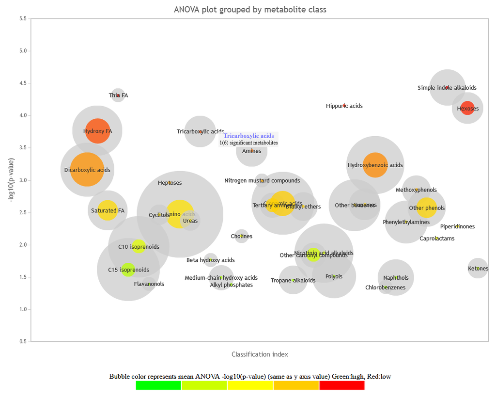

Podemos además comprobar, buscando los compuestos significativos observados previamente, sus categorías químicas (en la captura aparece, por ejemplo, la Sucralosa, Dihidroxifumarato y el metil beta-d-galactosido). Otros con significación patente han sido la Coenzima B, azinphos-ethyl

- NOTA: *Hay casos como el del Dichlorophen, que no es asignado a ninguna categoría y quizá por eso en este caso queda fuera de la significación. Otros sí aparecen, pero no son significativos, como Nitramine (benzeno), 5-Methyl-3-isoxazolyl sulfate, o el Decarbamoylgonyautoxin.*

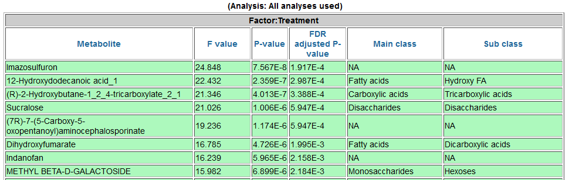

  *Primeros lugares*

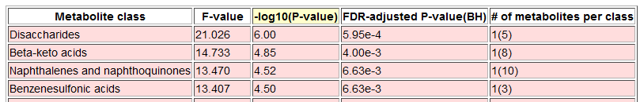

  *ÚItimos lugares*

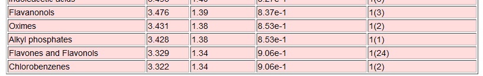

#### D) CONCLUSIÓN DE LA PREGUNTA BIOLÓGICA

Pese a que, según parece, los perfiles de orina muestran diferencias en su composición metabólica entre los grupos, el grupo de los flavonoides (al que pertenecen las procianidinas) presenta una significación débil, así que las diferencias significativas bien pueden deberse a la robustez de los tests utilizados en la web o a la naturaleza de los datos cargados, en lugar de a diferencias sustancialmente reales.

Por desgracia, los autores no concluyen ni dan una respuesta puesto que el set de datos pertenece a una demostración de uso del paquete bioinformático fobitools, demostración que no responde a la pregunta del estudio sino a la utilidad del paquete en sí para identificar Biomarcadores en la comida (Food Biomarker Ontology) a través de análisis de LCMS de los que se obtienen los identificadores químicos estandarizados (PubchemID, etc.).

**Por este motivo, intentamos extraer conclusiones propias:**

- Si a priori no hay una excreción significativamente diferente en orina de flavonoides, ni de conjugados glucosilados, y aunque [los procesos metabolicos a los que se someten las procianidinas en el organismo son mayormente desconocidos](https://riiit.com.mx/apps/site/files_v2450/litche_cd_valles._2_riiit_div_ene-feb_2023.pdf), es cierto que los compuestos fenólicos son sometidos a procesos de metilación o sulfatación y glucuronidación y que en el análisis de diferencias entre grupos los fenoles presentan diferencias significativas razonables
- Esto quiere decir que potencialmente hay una cantidad significativamente diferente de fenoles siendo expulsados (y potencialmente procesados antes en el organismo)

### 4. ANÁLISIS DE LOS DATOS: VARIANZA ENTRE TRATAMIENTOS

Vamos a llevar a cabo nuestro propio análisis

```r
#Primero comprobaremos la varianza entre los grupos de tratamiento. Vamos a asumir la normalidad de los datos puesto que es lo más común en las variables biológicas. Además, todos los registros proceden del mismo tipo de lectura (LCMS) así que todos están en la misma escala.

#En primer lugar vamos a añadir los nombres de los compuestos a la hoja de datos en crudo
datos_raw$Compuesto = comp_total[[1]]

#Limpiamos el data frame de los registros que presentan NA
datos_sin_na = na.omit(datos_raw)

#Convertimos el dataframe a formato largo para facilitar el análisis ANOVA
# Primero, seleccionamos solo las columnas de interés para pivotar
pacientes_cols = names(datos_sin_na)[grepl("^a|^b|^c", names(datos_sin_na))]

# Luego, pivotamos solo las columnas de pacientes
datos_pivotado = datos_sin_na %>%
  select(Compuesto, all_of(pacientes_cols)) %>%
  pivot_longer(
    cols = all_of(pacientes_cols),
    names_to = "Paciente",
    values_to = "Intensidad"
  ) %>%
  mutate(
    Grupo = case_when(
      str_starts(Paciente, "a") ~ "Manzana",
      str_starts(Paciente, "b") ~ "Base",
      str_starts(Paciente, "c") ~ "Arandano"
    )
  )

head(datos_pivotado)
```

```
## # A tibble: 6 × 4
##   Compuesto         Paciente Intensidad Grupo
##   <chr>             <chr>         <dbl> <chr>
## 1 10-Oxodecanoate_1 a1           135000 Manzana
## 2 10-Oxodecanoate_1 a10           56700 Manzana
## 3 10-Oxodecanoate_1 a11          911000 Manzana
## 4 10-Oxodecanoate_1 a12         1030000 Manzana
## 5 10-Oxodecanoate_1 a13          344000 Manzana
## 6 10-Oxodecanoate_1 a14           18800 Manzana
```

```r
#Segundo: Análisis estadístico compuesto por compuesto

# ANOVA: Creamos un nuevo df al que le añadimos la columna cone l p-valor correspondiente
anova_grupos = datos_pivotado %>%
  group_by(Compuesto) %>%
  summarise(
    p_value_anova = tryCatch(
      summary(aov(Intensidad ~ Grupo))[[1]][["Pr(>F)"]][1],
      error = function(e) NA
    )
  )

head(anova_grupos)
```

```
## # A tibble: 6 × 2
##   Compuesto               p_value_anova
##   <chr>                           <dbl>
## 1 (+)-Bornane-2,5-dione_1         0.418
## 2 (+)-Bornane-2,5-dione_2         0.652
## 3 (+)-Camphor_1                   0.940
## 4 (+)-Camphor_2                   0.712
## 5 (+)-Norephedrine_1              0.657
## 6 (+)-Norephedrine_2              0.584
```

```r
write.xlsx(anova_grupos, file="ANOVA_Grupos.xlsx",rownames=FALSE)
```

```r
#Tercero: Análisis post Hoc para determinar las diferencias entre tratamientos. Es decir entre qué grupos se presentan las diferencias significativas observadas

# Filtrado de compuestos significativos
compuestos_significativos = anova_grupos %>%
  filter(p_value_anova < 0.05)

# Inicializar una lista para almacenar los resultados del post hoc
resultados_posthoc = list()

# Análisis post hoc solo para compuestos significativos

for (i in 1:nrow(compuestos_significativos)) {
  compuesto = compuestos_significativos$Compuesto[i]

  # Realiza el análisis post hoc de Tukey
  posthoc_result = TukeyHSD(aov(Intensidad ~ Grupo, data = datos_pivotado[datos_pivotado$Compuesto == compuesto, ]))

  # Convierte los resultados a un dataframe y añade la columna de compuesto
  resultados_posthoc[[i]] = broom::tidy(posthoc_result) %>%
    select(contrast, estimate, conf.low, conf.high, adj.p.value) %>% # Selecciona las columnas deseadas
    mutate(Compuesto = compuesto)
}

# Combina todos los resultados post hoc en un solo dataframe
resultados_posthoc_df = bind_rows(resultados_posthoc)

# Filtra los resultados significativos
resultados_significativos = resultados_posthoc_df %>%
  filter(adj.p.value < 0.05)

# Separa los resultados por comparación
base_arandano = resultados_significativos %>% filter(grepl("Base-Arandano", contrast))
manzana_base = resultados_significativos %>% filter(grepl("Manzana-Base", contrast))
manzana_arandano = resultados_significativos %>% filter(grepl("Manzana-Arandano", contrast))

#Veremos las columnas de diferencia estimada, limites superior e inferior, además del p valor asociado. La diferencia se calcula como la sustracción del primer grupo al segundo, es decir:

# Si la diferencia estimada entre los grupos A-B es de 5, esto quiere decir que B-A = 5 unidades. Por tanto, valores positivos en los estimados indican que el segundo grupo presenta una intensidad (media) MAYOR para ese compuesto, y viceversa.

head(base_arandano)
```

```
## # A tibble: 6 × 6
##   contrast        estimate    conf.low  conf.high adj.p.value Compuesto
##   <chr>              <dbl>       <dbl>      <dbl>       <dbl> <chr>
## 1 Base-Arandano -19463300   -30845573.  -8081027.  0.000294   (3-Arylcarbonyl)-…
## 2 Base-Arandano -10877933.  -15394184.  -6361683.  0.00000192 (7R)-7-(5-Carboxy…
## 3 Base-Arandano  -4580167.   -8018843.  -1141490.  0.00656    (R)-(Homo)2-citra…
## 4 Base-Arandano -72161400  -103134937. -41187863.  0.00000362 (R)-2-Hydroxybuta…
## 5 Base-Arandano   -418272     -661365.   -175179.  0.000417   1,2-Diamino-4-nit…
## 6 Base-Arandano   -350842.    -685776.    -15908.  0.0383     2,4-Diamino-6-nit…
```

```r
head(manzana_base)
```

```
## # A tibble: 6 × 6
##   contrast       estimate   conf.low  conf.high adj.p.value Compuesto
##   <chr>             <dbl>      <dbl>      <dbl>       <dbl> <chr>
## 1 Manzana-Base   1639600     723433.  2555767.  0.000248    (R)-Mevalonate_1
## 2 Manzana-Base    -49537.    -99021.      -52.7 0.0497      1,2-Dihydroxy-5-(me…
## 3 Manzana-Base   -132700    -185568.   -79832.  0.000000851 12-Hydroxydodecanoi…
## 4 Manzana-Base -20036867. -39754190.  -319543.  0.0457      4-Acetamidobutanoat…
## 5 Manzana-Base   6245667.   1849792. 10641542.  0.00360     4-Hydroxybutanoic a…
## 6 Manzana-Base   1434387.    129926.  2738847.  0.0283      4-Oxocyclohexanecar…
```

```r
head(manzana_arandano)
```

```
## # A tibble: 6 × 6
##   contrast           estimate    conf.low  conf.high adj.p.value Compuesto
##   <chr>                 <dbl>       <dbl>      <dbl>       <dbl> <chr>
## 1 Manzana-Arandano   -103333.    -176150.    -30516.  0.00364    (-)-Menthyl ac…
## 2 Manzana-Arandano -19404900   -30787173.  -8022627.  0.000307   (3-Arylcarbony…
## 3 Manzana-Arandano  -8750000   -13266251.  -4233749.  0.0000801  (7R)-7-(5-Carb…
## 4 Manzana-Arandano  -4492040    -7930716.  -1053364.  0.00777    (R)-(Homo)2-ci…
## 5 Manzana-Arandano -72120353. -103093891. -41146816.  0.00000365 (R)-2-Hydroxyb…
## 6 Manzana-Arandano   1569400      653233.   2485567.  0.000442   (R)-Mevalonate…
```

```r
#Extraeremos los compuestos significativamente diferentes en los tratamientos. Cuidado con el  manzana_base, debemos invertido (<) por el orden en que se han contrastado)

base_arandano_positivos=subset(base_arandano, estimate > 0)
base_manzana_positivos=subset(manzana_base,estimate<0)

#Los siguientes compuestos son los que aparecen significativamente con más intensidad diferentes en un tratamiento con estos zumos.
compuestos_diferenciales_positivos=rbind(base_arandano_positivos,base_manzana_positivos)


cat("Los compuestos que ven incrementada su aparición en orina cuando se suministra Zumo de Arándano son:
    ", paste(unique(base_arandano_positivos$Compuesto), collapse = ","),
    "

    Los compuestos que ven incrementada su aparición en orina cuando se suministra Zumo de Manzana son :
    ", paste(unique(base_manzana_positivos$Compuesto), collapse = ", "))
```

[output not shown]

```r
#Guardamos en un excel con diferentes hojas este análisis, aunque sin el desglose, puesto que son archivos pequeños de excel con los que se puede trabajar sin problemas

wb = createWorkbook()

addWorksheet(wb, "Base-Arandano")
writeData(wb, "Base-Arandano", base_arandano)

addWorksheet(wb, "Manzana-Base")
writeData(wb, "Manzana-Base", manzana_base)

addWorksheet(wb, "Manzana-Arandano")
writeData(wb, "Manzana-Arandano", manzana_arandano)

saveWorkbook(wb, "resultados_posthoc.xlsx", overwrite = TRUE)
```

### 5. ORGANIZACIÓN DE RESULTADOS EN EL DIRECTORIO DE TRABAJO Y SUBIDA A GITHUB

```r
# Creamos una carpeta para almacenar los excels

carpeta_destino <- file.path(wd, "excel_resultados")

if (!dir.exists(carpeta_destino)) {
  dir.create(carpeta_destino)
}

# Obtiene la lista de archivos Excel en el directorio de trabajo
archivos_excel <- list.files(wd, pattern = "\\.xlsx$", full.names = TRUE)

# Mueve cada archivo Excel a la carpeta de destino
file.rename(archivos_excel, file.path(carpeta_destino, basename(archivos_excel)))
```

```
## [1] TRUE TRUE TRUE TRUE TRUE TRUE TRUE TRUE TRUE
```

Vamos ahora a subirlo al repositorio de GitHub

https://github.com/antartidan/PEC1_Omicos

```r
# Agregar todos los archivos y carpetas, excluyendo metaboData (como está especificado en el .gitignore)
system("git add .", intern = TRUE)
```

```
## character(0)
```

```r
# Realizar el commit
system("git commit -m \"Subida inicial de todos los archivos al repositorio PEC1_Omicos\"", intern = TRUE)
```

```
## [1] "[main 3fcab3f] Subida inicial de todos los archivos al repositorio PEC1_Omicos"
## [2] " 9 files changed, 0 insertions(+), 0 deletions(-)"
```

```r
# Eliminar cualquier remoto existente para evitar errores
system("git remote remove origin", intern = TRUE)
```

```
## character(0)
```

```r
# Configurar el remoto con el token
system("git remote add origin https://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@github.com/antartidan/PEC1_Omicos.git", intern = TRUE)
```

```
## character(0)
```

```r
# Hacer pull para asegurarse de que el repositorio local esté actualizado
pull_output <- system("git pull origin main", intern = TRUE)

# Verificar si el pull se realizó con éxito
if (any(grepl("Already up to date", pull_output))) {
  cat("El repositorio local ya está actualizado.\n")
} else {
  cat("El repositorio local fue actualizado.\n")
}
```

```
## El repositorio local ya está actualizado.
```

```r
# Hacer push a la rama principal
push_output <- system("git push -u origin main", intern = TRUE)

# Imprimir el resultado del push
cat(push_output, sep = "\n")
```

```
## branch 'main' set up to track 'origin/main'.
```